# Predicting the MPG (miles per gallon) of a car

```python
import warnings
warnings.filterwarnings('ignore')
%matplotlib inline
```

```python
import numpy as np
import pandas as pd
import time
import seaborn as sns
import matplotlib.pyplot as plt
import scipy.stats as stats
sns.set(style="whitegrid")
```

# ETL

```python
auto_mpg = pd.read_csv("auto-mpg.csv", header = 0)
auto_mpg.head()
```

|  | mpg | cylinders | displacement | horsepower | weight | acceleration | model year | origin | car name |
| --- | --- | --- | --- | --- | --- | --- | --- | --- | --- |
| 0 | 18.0 | 8 | 307.0 | 130 | 3504 | 12.0 | 70 | 1 | chevrolet chevelle malibu |
| 1 | 15.0 | 8 | 350.0 | 165 | 3693 | 11.5 | 70 | 1 | buick skylark 320 |
| 2 | 18.0 | 8 | 318.0 | 150 | 3436 | 11.0 | 70 | 1 | plymouth satellite |
| 3 | 16.0 | 8 | 304.0 | 150 | 3433 | 12.0 | 70 | 1 | amc rebel sst |
| 4 | 17.0 | 8 | 302.0 | 140 | 3449 | 10.5 | 70 | 1 | ford torino |

```python
auto_mpg.info()
```

```
<class 'pandas.core.frame.DataFrame'>
RangeIndex: 398 entries, 0 to 397
Data columns (total 9 columns):
mpg             398 non-null float64
cylinders       398 non-null int64
displacement    398 non-null float64
horsepower      398 non-null object
weight          398 non-null int64
acceleration    398 non-null float64
model year      398 non-null int64
origin          398 non-null int64
car name        398 non-null object
dtypes: float64(3), int64(4), object(2)
memory usage: 28.1+ KB
```

```python
auto_mpg = auto_mpg.replace('?',np.NaN)
print("missing values:")
for col in auto_mpg.columns:
    print(col,auto_mpg[col].isna().sum())
print("number of rows: ", len(auto_mpg))
```

```
missing values:
mpg 0
cylinders 0
displacement 0
horsepower 6
weight 0
acceleration 0
model year 0
origin 0
car name 0
number of rows:  398
```

Since there is only 6/398 missing horesepower data, we will drop those rows

```python
auto_mpg = auto_mpg.dropna()
for col in auto_mpg.columns:
    print(col,auto_mpg[col].isna().sum())
```

```
mpg 0
cylinders 0
displacement 0
horsepower 0
weight 0
acceleration 0
model year 0
origin 0
car name 0
```

# EDA

## Single Variables

We start with the single variable EDA of all the features provided in the data.\ MPG: MPG is a continuous float variable that is the miles per gallon of the car

```python
auto_mpg["mpg"].describe()
```

```
count    392.000000
mean      23.445918
std        7.805007
min        9.000000
25%       17.000000
50%       22.750000
75%       29.000000
max       46.600000
Name: mpg, dtype: float64
```

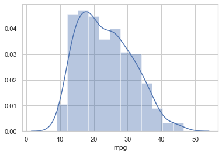

```python
sns.distplot(auto_mpg["mpg"])
```

Cylinders: Cylinders multi-valued discrete variable that is the number of cylinders a car has

```
count    392.000000
mean       5.471939
std        1.705783
min        3.000000
25%        4.000000
50%        4.000000
75%        8.000000
max        8.000000
Name: cylinders, dtype: float64
```

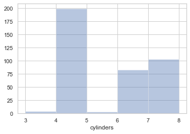

```python
print(auto_mpg["cylinders"].describe())
sns.distplot(auto_mpg["cylinders"],kde=False)
```

```python
auto_mpg["cylinders"].value_counts()
```

```
4    199
8    103
6     83
3      4
5      3
Name: cylinders, dtype: int64
```

There are mainly only 4,6, and 8 cylinder engines in the data with majority being 4 cylinder.

Displacement: A continuous variable that is the measure of the cylinder volume swept by all of the pistons of a piston engine, excluding the combustion chambers.

```
count    392.000000
mean     194.411990
std      104.644004
min       68.000000
25%      105.000000
50%      151.000000
75%      275.750000
max      455.000000
Name: displacement, dtype: float64
```

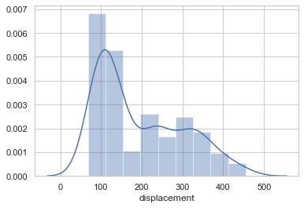

```python
print(auto_mpg["displacement"].describe())
sns.distplot(auto_mpg["displacement"],kde=True)
```

Displacement seems rightly skewed

Horse Power: Horsepower is a continuous variable which is the horsepower of the car

```
count    392.000000
mean     104.469388
std       38.491160
min       46.000000
25%       75.000000
50%       93.500000
75%      126.000000
max      230.000000
Name: horsepower, dtype: float64
```

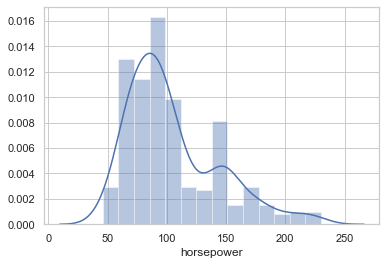

```python
auto_mpg["horsepower"] = auto_mpg["horsepower"].astype(float)
print(auto_mpg["horsepower"].describe())
sns.distplot(auto_mpg["horsepower"])
```

horsepower is slightly rightly skewed

Weight: Weight is a continuous variable that is the weight of the car

```
count     392.000000
mean     2977.584184
std       849.402560
min      1613.000000
25%      2225.250000
50%      2803.500000
75%      3614.750000
max      5140.000000
Name: weight, dtype: float64
```

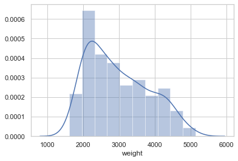

```python
print(auto_mpg["weight"].describe())
sns.distplot(auto_mpg["weight"])
```

weight is slightly rightly skewed

Acceleration: A continuous variable that is the acceleration of the car which would be in meters per second squared

```
count    392.000000
mean      15.541327
std        2.758864
min        8.000000
25%       13.775000
50%       15.500000
75%       17.025000
max       24.800000
Name: acceleration, dtype: float64
```

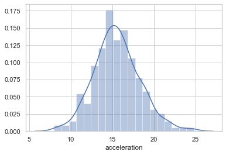

```python
print(auto_mpg["acceleration"].describe())
sns.distplot(auto_mpg["acceleration"])
```

acceleration looks almost perfectly normally distributed

Model year is a multi-valued discrete variable that is the year the car was made

```
count    392.000000
mean      75.979592
std        3.683737
min       70.000000
25%       73.000000
50%       76.000000
75%       79.000000
max       82.000000
Name: model year, dtype: float64
```

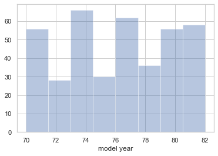

```python
print(auto_mpg["model year"].describe())
sns.distplot(auto_mpg["model year"], kde = False)
```

Origin is a multi-valued discrete that means: 1 is a car made in america, 2 in europe and 3 in asia or other part of the world

```
count    392.000000
mean       1.576531
std        0.805518
min        1.000000
25%        1.000000
50%        1.000000
75%        2.000000
max        3.000000
Name: origin, dtype: float64
```

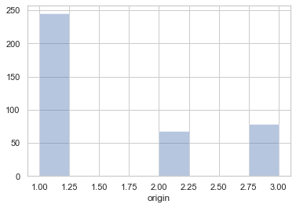

```python
print(auto_mpg["origin"].describe())
sns.distplot(auto_mpg["origin"], kde = False)
```

```python
auto_mpg["origin"].value_counts()
```

```
1    245
3     79
2     68
Name: origin, dtype: int64
```

most of the cars in the data are from the United States

Car name is a string variable that is the name of the car but preprocessing is necessary to fix spelling mistakes and find the make of the car:

```python
print(auto_mpg["car name"].unique)
```

```
<bound method Series.unique of 0              chevrolet chevelle malibu
1                      buick skylark 320
2                     plymouth satellite
3                          amc rebel sst
4                            ford torino
5                       ford galaxie 500
6                       chevrolet impala
7                      plymouth fury iii
8                       pontiac catalina
9                     amc ambassador dpl
10                   dodge challenger se
11                    plymouth 'cuda 340
12                 chevrolet monte carlo
13               buick estate wagon (sw)
14                 toyota corona mark ii
```

[output cut: 47 more lines]

```python
auto_mpg["make"] = auto_mpg["car name"].str.split().str.get(0)

auto_mpg["make"] = auto_mpg["make"].replace(to_replace ='mercedes-benz',value ='mercedes')
auto_mpg["make"] = auto_mpg["make"].replace(to_replace ='vw',value ='vokswagen')
auto_mpg["make"] = auto_mpg["make"].replace(to_replace ='toyouta',value ='toyota')
auto_mpg["make"] = auto_mpg["make"].replace(to_replace ='chevroelt',value ='chevrolet')
auto_mpg["make"] = auto_mpg["make"].replace(to_replace ='maxda',value ='mazda')
print(auto_mpg["make"].unique())
```

```
['chevrolet' 'buick' 'plymouth' 'amc' 'ford' 'pontiac' 'dodge' 'toyota'
 'datsun' 'volkswagen' 'peugeot' 'audi' 'saab' 'bmw' 'chevy' 'hi'
 'mercury' 'opel' 'fiat' 'oldsmobile' 'chrysler' 'mazda' 'volvo' 'renault'
 'honda' 'subaru' 'capri' 'vokswagen' 'mercedes' 'cadillac' 'triumph'
 'nissan']
```

```python
print(auto_mpg["make"].describe())
print(auto_mpg["make"].value_counts())
#sns.barplot(x=auto_mpg["make"].value_counts().index, y=auto_mpg["make"].value_counts())
```

```
count      392
unique      32
top       ford
freq        48
Name: make, dtype: object
ford          48
chevrolet     44
plymouth      31
dodge         28
amc           27
toyota        26
datsun        23
buick         17
pontiac       16
volkswagen    15
honda         13
mazda         12
mercury       11
oldsmobile    10
fiat           8
peugeot        8
audi           7
vokswagen      7
volvo          6
chrysler       6
opel           4
saab           4
subaru         4
chevy          3
mercedes       3
renault        3
cadillac       2
bmw            2
capri          1
nissan         1
hi             1
triumph        1
Name: make, dtype: int64
```

## Pairwise EDA

```python
import statsmodels.api as sm
def correlation(data, x, y):
    print("Correlation coefficients:")
    print( "r   =", stats.pearsonr(data[x], data[y])[0])
    print( "rho =", stats.spearmanr(data[x], data[y])[0])
def describe_by_category(data, numeric, categorical):
    grouped = data.groupby(categorical)
    grouped_y = grouped[numeric].describe()
    print(grouped_y)
def lowess_scatter(data, x, y, jitter=0.0, skip_lowess=False):
    if skip_lowess:
        fit = np.polyfit(data[x], data[y], 1)
        line_x = np.linspace(data[x].min(), data[x].max(), 10)
        line = np.poly1d(fit)
        line_y = list(map(line, line_x))
    else:
        lowess = sm.nonparametric.lowess(data[y], data[x], frac=.3)
        line_x = list(zip(*lowess))[0]
        line_y = list(zip(*lowess))[1]

    figure = plt.figure(figsize=(10, 6))

    axes = figure.add_subplot(1, 1, 1)

    xs = data[x]
    if jitter > 0.0:
        xs = data[x] + stats.norm.rvs( 0, 0.5, data[x].size)

    axes.scatter(xs, data[y], marker="o", color="DimGray", alpha=0.5)
    axes.plot(line_x, line_y, color="DarkRed")

    title = "Plot of {0} v. {1}".format(x, y)
    if not skip_lowess:
        title += " with LOWESS"
    axes.set_title(title)
    axes.set_xlabel(x)
    axes.set_ylabel(y)

    plt.show()
    plt.close()

def multiboxplot(data, numeric, categorical, skip_data_points=True):
    figure = plt.figure(figsize=(10, 6))

    axes = figure.add_subplot(1, 1, 1)

    grouped = data.groupby(categorical)
    labels = pd.unique(data[categorical].values)
    labels.sort()
    grouped_data = [grouped[numeric].get_group( k) for k in labels]
    patch = axes.boxplot( grouped_data, labels=labels, patch_artist=True, zorder=1)
    eda.restyle_boxplot( patch)

    if not skip_data_points:
        for i, k in enumerate(labels):
            subdata = grouped[numeric].get_group( k)
            x = np.random.normal(i + 1, 0.01, size=len(subdata))
            axes.plot(x, subdata, 'o', alpha=0.4, color="DimGray", zorder=2)

    axes.set_xlabel(categorical)
    axes.set_ylabel(numeric)
    axes.set_title("Distribution of {0} by {1}".format(numeric, categorical))

    plt.show()
    plt.close()
```

I expect cylinders to be negatively correlated with mpg:

```python
correlation(auto_mpg, "cylinders", "mpg")
```

```
Correlation coefficients:
r   = -0.7776175081260226
rho = -0.8231746391245731
```

```python
describe_by_category(auto_mpg, "mpg", "cylinders")
```

```
           count       mean       std   min    25%    50%    75%   max
cylinders
3            4.0  20.550000  2.564501  18.0  18.75  20.25  22.05  23.7
4          199.0  29.283920  5.670546  18.0  25.00  28.40  32.95  46.6
5            3.0  27.366667  8.228204  20.3  22.85  25.40  30.90  36.4
6           83.0  19.973494  3.828809  15.0  18.00  19.00  21.00  38.0
8          103.0  14.963107  2.836284   9.0  13.00  14.00  16.00  26.6
```

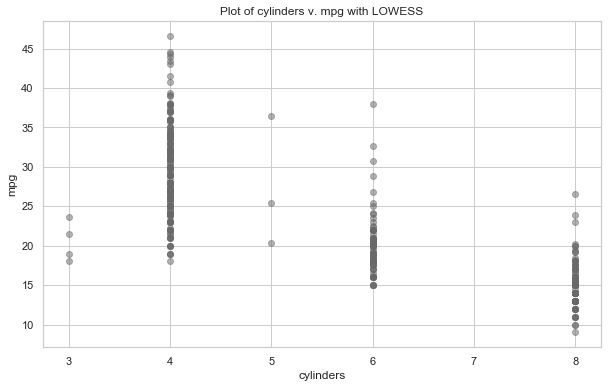

```python
lowess_scatter(auto_mpg,"cylinders","mpg")
```

My hypothesis was correct, when the number of cylinders increases, the overall range of mpg decreases

I expect displacement to be negatively correlated with mpg:

```python
correlation(auto_mpg, "displacement", "mpg")
```

```
Correlation coefficients:
r   = -0.8051269467104578
rho = -0.8552335882841171
```

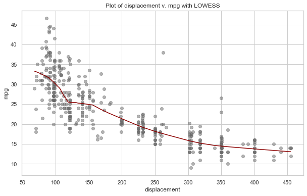

```python
lowess_scatter(auto_mpg,"displacement","mpg")
```

My hypoethesis was correct; when displacement increases mpg decreases

I also expect horsepower to be negatively correlated with mpg:

```python
correlation(auto_mpg, "horsepower", "mpg")
```

```
Correlation coefficients:
r   = -0.7784267838977761
rho = -0.8536164024453882
```

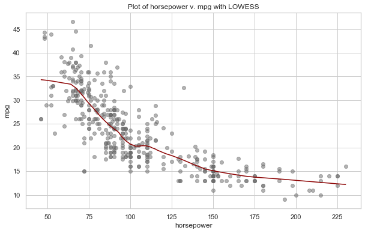

```python
lowess_scatter(auto_mpg,"horsepower","mpg")
```

My hypoethesis was correct; when horsepower increases mpg decreases

I expect weight to be negatively correlated with mpg:

```python
correlation(auto_mpg, "weight", "mpg")
```

```
Correlation coefficients:
r   = -0.8322442148315755
rho = -0.8755851198739869
```

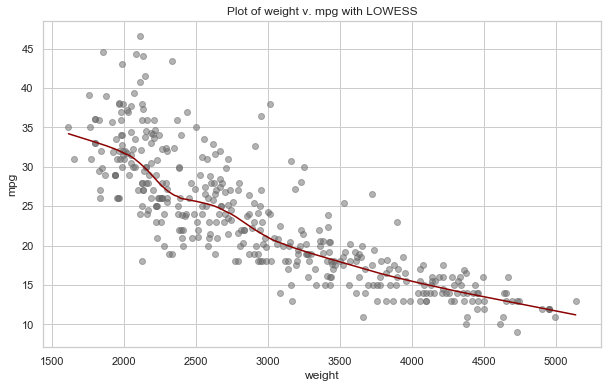

```python
lowess_scatter(auto_mpg,"weight","mpg")
```

My hypoethesis was correct; when weight increases mpg decreases

I expect acceleration to be positively correlated with mpg:

```python
correlation(auto_mpg, "acceleration", "mpg")
```

```
Correlation coefficients:
r   = 0.42332853690278727
rho = 0.4415388584563648
```

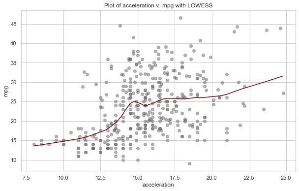

```python
lowess_scatter(auto_mpg,"acceleration","mpg")
```

My hypoethesis was correct; when acceleration increases mpg increases

I expect model year to be positively correlated with mpg because newer cars would be more fuel efficient:

```python
correlation(auto_mpg, "model year", "mpg")
```

```
Correlation coefficients:
r   = 0.5805409660907856
rho = 0.5748408744472728
```

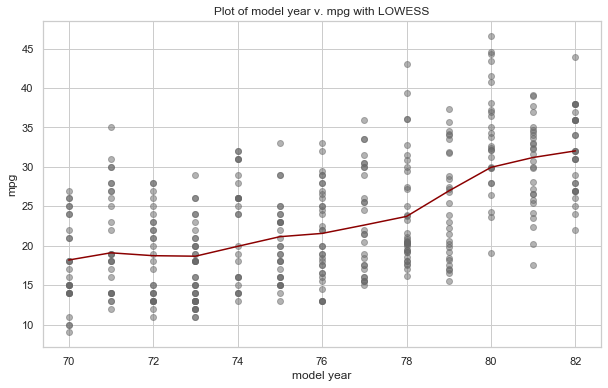

```python
lowess_scatter(auto_mpg,"model year","mpg")
```

```python
describe_by_category(auto_mpg, "mpg", "model year")
```

```
            count       mean       std   min     25%    50%     75%   max
model year
70           29.0  17.689655  5.339231   9.0  14.000  16.00  22.000  27.0
71           27.0  21.111111  6.675635  12.0  15.000  19.00  27.000  35.0
72           28.0  18.714286  5.435529  11.0  13.750  18.50  23.000  28.0
73           40.0  17.100000  4.700245  11.0  13.000  16.00  20.000  29.0
74           26.0  22.769231  6.537937  13.0  16.000  24.50  27.500  32.0
75           30.0  20.266667  4.940566  13.0  16.000  19.50  23.000  33.0
76           34.0  21.573529  5.889297  13.0  16.750  21.00  26.375  33.0
77           28.0  23.375000  6.675862  15.0  17.375  21.75  30.000  36.0
78           36.0  24.061111  6.898044  16.2  19.350  20.70  28.000  43.1
79           29.0  25.093103  6.794217  15.5  19.200  23.90  31.800  37.3
80           27.0  33.803704  6.885854  19.1  29.800  32.70  37.650  46.6
81           28.0  30.185714  5.635319  17.6  26.400  31.15  34.175  39.1
82           30.0  32.000000  5.232524  22.0  27.250  32.00  36.000  44.0
```

My hypoethesis was correct; when model year increases mpg increases

I would expect cars in asia to have better mpg from personal experience of driving hondas and toyotas

```python
describe_by_category(auto_mpg, "mpg", "origin")
```

```
        count       mean       std   min    25%   50%     75%   max
origin
1       245.0  20.033469  6.440384   9.0  15.00  18.5  24.000  39.0
2        68.0  27.602941  6.580182  16.2  23.75  26.0  30.125  44.3
3        79.0  30.450633  6.090048  18.0  25.70  31.6  34.050  46.6
```

My hypoethesis was corect; asian cars had the highest mpg but American cars had a far worse mpg compared to asian and european cars

```python
describe_by_category(auto_mpg, "mpg", "make")
```

```
            count       mean        std   min     25%    50%     75%   max
make
amc          27.0  18.070370   3.225358  13.0  15.750  18.00  19.200  27.4
audi          7.0  26.714286   6.632855  20.0  21.650  24.00  31.650  36.4
bmw           2.0  23.750000   3.181981  21.5  22.625  23.75  24.875  26.0
buick        17.0  19.182353   5.760993  12.0  14.000  17.70  22.400  30.0
cadillac      2.0  19.750000   4.596194  16.5  18.125  19.75  21.375  23.0
capri         1.0  25.000000        NaN  25.0  25.000  25.00  25.000  25.0
chevrolet    44.0  20.370455   6.147587  11.0  15.375  18.60  25.500  34.0
chevy         3.0  18.000000  11.357817  10.0  11.500  13.00  22.000  31.0
chrysler      6.0  17.266667   4.846304  13.0  13.625  16.55  18.275  26.0
datsun       23.0  31.113043   5.721674  22.0  27.000  32.00  36.000  40.8
dodge        28.0  22.060714   7.574144  11.0  15.375  19.70  28.000  36.0
fiat          8.0  28.912500   4.102765  24.0  26.000  28.50  30.250  37.3
ford         48.0  19.475000   5.936383  10.0  14.375  18.05  23.250  36.1
hi            1.0   9.000000        NaN   9.0   9.000   9.00   9.000   9.0
honda        13.0  33.761538   4.764371  24.0  32.000  33.00  36.000  44.6
mazda        12.0  30.058333   8.247144  18.0  23.150  31.45  34.100  46.6
mercedes      3.0  23.966667   6.863187  16.5  20.950  25.40  27.700  30.0
mercury      11.0  19.118182   6.822143  11.0  15.000  19.80  20.900  36.0
nissan        1.0  36.000000        NaN  36.0  36.000  36.00  36.000  36.0
oldsmobile   10.0  21.100000   8.494181  11.0  13.250  21.85  25.925  38.0
opel          4.0  25.750000   1.707825  24.0  24.750  25.50  26.500  28.0
peugeot       8.0  23.687500   4.767580  16.2  20.500  24.00  27.425  30.0
plymouth     31.0  21.703226   7.792367  13.0  15.500  19.00  25.750  39.0
pontiac      16.0  20.012500   6.285632  13.0  15.500  18.75  23.375  33.5
renault       3.0  29.666667   5.507571  26.0  26.500  27.00  31.500  36.0
saab          4.0  23.900000   1.604161  21.6  23.400  24.50  25.000  25.0
subaru        4.0  30.525000   3.397425  26.0  29.000  31.15  32.675  33.8
toyota       26.0  28.165385   5.644320  19.0  24.000  27.75  32.000  39.1
triumph       1.0  35.000000        NaN  35.0  35.000  35.00  35.000  35.0
vokswagen     7.0  37.700000   7.093659  29.0  30.850  41.50  43.700  44.3
volkswagen   15.0  29.106667   5.374472  22.0  26.000  29.00  31.000  43.1
volvo         6.0  21.116667   5.000167  17.0  18.250  19.50  21.500  30.7
```

## Building the model

```python
auto_mpg.head()
```

|  | mpg | cylinders | displacement | horsepower | weight | acceleration | model year | origin | car name | make |
| --- | --- | --- | --- | --- | --- | --- | --- | --- | --- | --- |
| 0 | 18.0 | 8 | 307.0 | 130.0 | 3504 | 12.0 | 70 | 1 | chevrolet chevelle malibu | chevrolet |
| 1 | 15.0 | 8 | 350.0 | 165.0 | 3693 | 11.5 | 70 | 1 | buick skylark 320 | buick |
| 2 | 18.0 | 8 | 318.0 | 150.0 | 3436 | 11.0 | 70 | 1 | plymouth satellite | plymouth |
| 3 | 16.0 | 8 | 304.0 | 150.0 | 3433 | 12.0 | 70 | 1 | amc rebel sst | amc |
| 4 | 17.0 | 8 | 302.0 | 140.0 | 3449 | 10.5 | 70 | 1 | ford torino | ford |

```python
#creating dummy variables for categorical features
auto_mpg = pd.concat([auto_mpg, pd.get_dummies(auto_mpg["cylinders"], prefix="cylinders")], axis=1)
auto_mpg = pd.concat([auto_mpg, pd.get_dummies(auto_mpg["origin"], prefix="origin")], axis=1)
auto_mpg.head()
```

|  | mpg | cylinders | displacement | horsepower | weight | acceleration | model year | origin | car name | make | cylinders_3 | cylinders_4 | cylinders_5 | cylinders_6 | cylinders_8 | origin_1 | origin_2 | origin_3 |
| --- | --- | --- | --- | --- | --- | --- | --- | --- | --- | --- | --- | --- | --- | --- | --- | --- | --- | --- |
| 0 | 18.0 | 8 | 307.0 | 130.0 | 3504 | 12.0 | 70 | 1 | chevrolet chevelle malibu | chevrolet | 0 | 0 | 0 | 0 | 1 | 1 | 0 | 0 |
| 1 | 15.0 | 8 | 350.0 | 165.0 | 3693 | 11.5 | 70 | 1 | buick skylark 320 | buick | 0 | 0 | 0 | 0 | 1 | 1 | 0 | 0 |
| 2 | 18.0 | 8 | 318.0 | 150.0 | 3436 | 11.0 | 70 | 1 | plymouth satellite | plymouth | 0 | 0 | 0 | 0 | 1 | 1 | 0 | 0 |
| 3 | 16.0 | 8 | 304.0 | 150.0 | 3433 | 12.0 | 70 | 1 | amc rebel sst | amc | 0 | 0 | 0 | 0 | 1 | 1 | 0 | 0 |
| 4 | 17.0 | 8 | 302.0 | 140.0 | 3449 | 10.5 | 70 | 1 | ford torino | ford | 0 | 0 | 0 | 0 | 1 | 1 | 0 | 0 |

Due to the high number of categories in make and car name, we will leave those variables out of the model and use origin as our primary variable for car manufacturer.

```python
def correlations(data, y, xs):
    rs = []
    rhos = []
    for x in xs:
        r = stats.pearsonr(data[y], data[x])[0]
        rs.append(r)
        rho = stats.spearmanr(data[y], data[x])[0]
        rhos.append(rho)
    return pd.DataFrame({"feature": xs, "r": rs, "rho": rhos})

correlations(auto_mpg, "mpg", ["cylinders_3", "cylinders_4", "cylinders_5", "cylinders_6","cylinders_8",
                                    "cylinders", "model year", "origin", "origin_1", "origin_2", "origin_3",
                               "displacement","horsepower","weight","acceleration"])
```

|  | feature | r | rho |
| --- | --- | --- | --- |
| 0 | cylinders_3 | -0.037721 | -0.032200 |
| 1 | cylinders_4 | 0.760490 | 0.793502 |
| 2 | cylinders_5 | 0.044171 | 0.047614 |
| 3 | cylinders_6 | -0.230873 | -0.211496 |
| 4 | cylinders_8 | -0.649667 | -0.707095 |
| 5 | cylinders | -0.777618 | -0.823175 |
| 6 | model year | 0.580541 | 0.574841 |
| 7 | origin | 0.565209 | 0.580482 |
| 8 | origin_1 | -0.565161 | -0.571642 |
| 9 | origin_2 | 0.244313 | 0.253350 |
| 10 | origin_3 | 0.451454 | 0.450745 |
| 11 | displacement | -0.805127 | -0.855234 |
| 12 | horsepower | -0.778427 | -0.853616 |
| 13 | weight | -0.832244 | -0.875585 |
| 14 | acceleration | 0.423329 | 0.441539 |

1. cylinders - There is a definite relationship for cylinders_4 and cylinders_8 but for the others, the relationship is weak or none. Looking at cylinders together had a stronger relationship than looking at either individually.
2. model year - moderately strong relationship.
3. origin - origin_1 and origin_3 had moderately strong linear relationship with mpg but origin_2 had a weaker relationship. Looking at origins together had a stronger relationship than looking at either individually.
4. Displacement - definite relationship
5. horsepower - definite relationship
6. weight - definite relationship
7. acceleration - moderately strong relationship and spearmans suggests that it is linear

```python
auto_mpg.mpg.describe()
```

```
count    392.000000
mean      23.445918
std        7.805007
min        9.000000
25%       17.000000
50%       22.750000
75%       29.000000
max       46.600000
Name: mpg, dtype: float64
```

```python
import models
auto_mpg["model_year"] = auto_mpg["model year"]
model = "mpg ~ cylinders_4  + cylinders_8 + model_year + origin_1 + origin_3 + displacement + horsepower + weight + acceleration"
result1 = models.bootstrap_linear_regression(model, data=auto_mpg)
models.describe_bootstrap_lr(result1)
```

**Model: mpg ~ cylinders_4 + cylinders_8 + model_year + origin_1 + origin_3 + displacement + horsepower + weight + acceleration**

|  |  |  | **95% BCI** |  |
| --- | --- | --- | --- | --- |
| **Coefficients** |  | **Mean** | **Lo** | **Hi** |
|  | $\beta_{0}$ | -18.61 | -27.46 | -9.96 |
| cylinders_4 | $\beta_{1}$ | 3.62 | 2.30 | 4.87 |
| cylinders_8 | $\beta_{2}$ | 1.55 | 0.31 | 2.80 |
| model_year | $\beta_{3}$ | 0.75 | 0.68 | 0.85 |
| origin_1 | $\beta_{4}$ | -2.06 | -3.34 | -0.95 |
| origin_3 | $\beta_{5}$ | 0.53 | -0.76 | 1.75 |
| displacement | $\beta_{6}$ | 0.02 | 0.01 | 0.04 |
| horsepower | $\beta_{7}$ | -0.04 | -0.07 | -0.01 |
| weight | $\beta_{8}$ | -0.01 | -0.01 | -0.00 |
| acceleration | $\beta_{9}$ | 0.05 | -0.25 | 0.34 |
| **Metrics** | **Mean** | **Lo** | **Hi** |  |
| $\sigma$ | 3.12 | 2.80 | 3.40 |  |
| $R^2$ | 0.84 | 0.82 | 0.87 |  |

I suspect that only including 4 and 8 cylinders in the model is a bad idea since we would be trading 6 cylinder engines the same as 3 cylinder engines which does not make any sense. I changed the model to include cylinders as a numerical variable instead of a categorical since we expect the number of cylinders to have a negative correlation with mpg.

From EDA, we also saw that distribution of mpg for origin_1 (usa) was far more distinct from europe and asia (2 and 3) which were similar. I took out origin_3 from the model since the confidence interval was both in the negatives and positives. It also made more sense to include only if it is of us origin or not since the distribution of mpg in asia and europe is similar.

```python
auto_mpg["origin_usa"] = auto_mpg["origin_1"]
model = "mpg ~ cylinders + model_year + origin_usa + displacement + horsepower + weight + acceleration"
result1 = models.bootstrap_linear_regression(model, data=auto_mpg)
models.describe_bootstrap_lr(result1)
```

**Model: mpg ~ cylinders + model_year + origin_usa + displacement + horsepower + weight + acceleration**

|  |  |  | **95% BCI** |  |
| --- | --- | --- | --- | --- |
| **Coefficients** |  | **Mean** | **Lo** | **Hi** |
|  | $\beta_{0}$ | -15.47 | -25.86 | -5.35 |
| cylinders | $\beta_{1}$ | -0.48 | -1.09 | -0.02 |
| model_year | $\beta_{2}$ | 0.78 | 0.69 | 0.89 |
| origin_usa | $\beta_{3}$ | -2.75 | -3.87 | -1.60 |
| displacement | $\beta_{4}$ | 0.02 | 0.01 | 0.04 |
| horsepower | $\beta_{5}$ | -0.02 | -0.05 | 0.01 |
| weight | $\beta_{6}$ | -0.01 | -0.01 | -0.01 |
| acceleration | $\beta_{7}$ | 0.08 | -0.15 | 0.28 |
| **Metrics** | **Mean** | **Lo** | **Hi** |  |
| $\sigma$ | 3.30 | 2.96 | 3.54 |  |
| $R^2$ | 0.82 | 0.80 | 0.85 |  |

Since acceleration had one of the weakest r and rho values among the feafeatures in the model, I decided to try a linear regression without acceleration:

```python
model = "mpg ~ cylinders + model_year + origin_usa + displacement + horsepower + weight"
result1 = models.bootstrap_linear_regression(model, data=auto_mpg)
models.describe_bootstrap_lr(result1)
```

**Model: mpg ~ cylinders + model_year + origin_usa + displacement + horsepower + weight**

|  |  |  | **95% BCI** |  |
| --- | --- | --- | --- | --- |
| **Coefficients** |  | **Mean** | **Lo** | **Hi** |
|  | $\beta_{0}$ | -13.84 | -21.26 | -7.49 |
| cylinders | $\beta_{1}$ | -0.50 | -0.99 | 0.03 |
| model_year | $\beta_{2}$ | 0.78 | 0.69 | 0.86 |
| origin_usa | $\beta_{3}$ | -2.75 | -3.81 | -1.98 |
| displacement | $\beta_{4}$ | 0.02 | 0.01 | 0.04 |
| horsepower | $\beta_{5}$ | -0.02 | -0.04 | -0.01 |
| weight | $\beta_{6}$ | -0.01 | -0.01 | -0.01 |
| **Metrics** | **Mean** | **Lo** | **Hi** |  |
| $\sigma$ | 3.30 | 3.01 | 3.59 |  |
| $R^2$ | 0.82 | 0.80 | 0.85 |  |

## Describing the final model

What about coefficients:

The intercept isn't particularly interesting here because there are no cars with 0 cylinders 0 model year 0 origin 0 displacement 0 horsepower and 0 weight.

Cylinders is negative and mostly supported by the data.\ Model_year is positive and strongly supported by the data\ Origin_usa is negative and strongly supported by the data.\ Displacement is positive and strongly supported by the data.\ Horsepower is negative and strongly supported by the data.\ Weight is negative and strongly supported by the data.

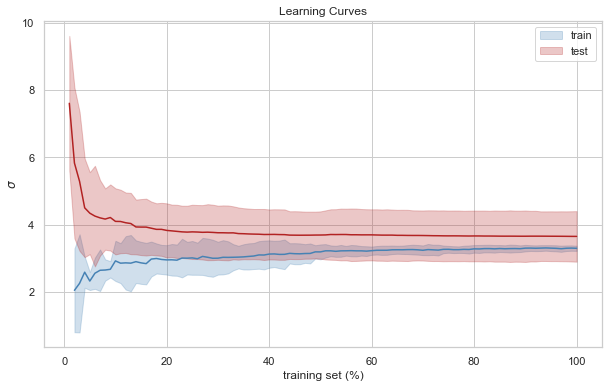

```python
from collections import defaultdict
import random
import patsy

def chunk(xs, n):
    k, m = divmod(len(xs), n)
    return [xs[i * k + min(i, m):(i + 1) * k + min(i + 1, m)] for i in range(n)]
def data_collection():
    result = dict()
    result[ "train"] = defaultdict( list)
    result[ "test"] = defaultdict( list)
    return result
def learning_curves(algorithm, formula, data, evaluate, fold_count=10, repetitions=3, increment=1):
    indices = list(range(len( data)))
    results = data_collection()
    for _ in range(repetitions):
        random.shuffle(indices)
        folds = chunk(indices, fold_count)
        for fold in folds:
            test_data = data.iloc[ fold]
            train_indices = [idx for idx in indices if idx not in fold]
            train_data = data.iloc[train_indices]
            for i in list(range(increment, 100, increment)) + [100]: # ensures 100% is always picked.
                # the indices are already shuffled so we only need to take ever increasing chunks
                train_chunk_size = int( np.ceil((i/100)*len( train_indices)))
                train_data_chunk = data.iloc[train_indices[0:train_chunk_size]]
                # we calculate the model
                result = algorithm(formula, data=train_data_chunk)
                model = result["model"]
                # we calculate the results for the training data subset
                y, X = patsy.dmatrices( formula, train_data_chunk, return_type="matrix")
                result = models.summarize(formula, X, y, model)
                metric = evaluate(result)
                results["train"][i].append( metric)

                # we calculate the results for the test data.
                y, X = patsy.dmatrices( formula, test_data, return_type="matrix")
                result = models.summarize(formula, X, y, model)
                metric = evaluate(result)
                results["test"][i].append( metric)
            #
    statistics = {}
    for k, v in results["train"].items():
        statistics[ k] = (np.mean(v), np.std(v))
    results["train"] = statistics
    statistics = {}
    for k, v in results["test"].items():
        statistics[ k] = (np.mean(v), np.std(v))
    results["test"] = statistics
    return results
#
def results_to_curves( curve, results):
    all_statistics = results[ curve]
    keys = list( all_statistics.keys())
    keys.sort()
    mean = []
    upper = []
    lower = []
    for k in keys:
        m, s = all_statistics[ k]
        mean.append( m)
        upper.append( m + 2 * s)
        lower.append( m - 2 * s)
    return keys, lower, mean, upper
def plot_learning_curves( results, metric, zoom=False):
    figure = plt.figure(figsize=(10,6))

    axes = figure.add_subplot(1, 1, 1)

    xs, train_lower, train_mean, train_upper = results_to_curves( "train", results)
    _, test_lower, test_mean, test_upper = results_to_curves( "test", results)

    axes.plot( xs, train_mean, color="steelblue")
    axes.fill_between( xs, train_upper, train_lower, color="steelblue", alpha=0.25, label="train")
    axes.plot( xs, test_mean, color="firebrick")
    axes.fill_between( xs, test_upper, test_lower, color="firebrick", alpha=0.25, label="test")
    axes.legend()
    axes.set_xlabel( "training set (%)")
    axes.set_ylabel( metric)
    axes.set_title("Learning Curves")

    if zoom:
        y_lower = int( 0.9 * np.amin([train_lower[-1], test_lower[-1]]))
        y_upper = int( 1.1 * np.amax([train_upper[-1], test_upper[-1]]))
        axes.set_ylim((y_lower, y_upper))

    plt.show()
    plt.close()
#

formula = "mpg ~ cylinders + model_year + origin_usa + displacement + horsepower + weight"
result = learning_curves(models.linear_regression, formula, auto_mpg, lambda r: r["sigma"])
plot_learning_curves(result, r"$\sigma$")
```

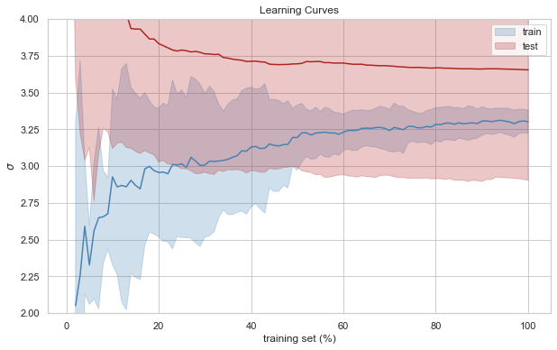

```python
plot_learning_curves(result, r"$\sigma$", zoom=True)
```

As the training set % increased, the mean standard deviation for train and test set did converge more but they never quite intersected, which suggests that more data can make the model a little better but not by much. Even with the data given however, the model achieved a standard deviation 95% confidence interval < 5.

## Using the model

Suppose Fred has a car with 6 cylinders, a displacement of 300, horsepower of 300, weight of 2500, acceleration of 17, with the model year being 1980 in the United States.

If we just look at the Null model, we have a estimated mpg of:

```python
auto_mpg.mpg.mean()
```

```
23.44591836734694
```

with an error of:

```python
auto_mpg.mpg.std()
```

```
7.805007486571799
```

```python
[auto_mpg.mpg.mean(), auto_mpg.mpg.mean() - 1.96*auto_mpg.mpg.std(), auto_mpg.mpg.mean() + 1.96*auto_mpg.mpg.std()]
```

```
[23.44591836734694, 8.148103693666217, 38.74373304102767]
```

We estimate that the mpg will be 23.4459 with a range of 8.1481 to 38.7437.

Let's see how our linear regression model does. We need a feature vector for Fred's car:

```python
freds_car = [1, 6, 80, 1, 300, 300, 2500]
```

```python
prediction = result1["model"].predict([freds_car])
prediction
```

```
array([[26.06457655]])
```

with an error of 3.3 mpg which leads to error bounds of:

```python
[prediction[0][0] - 1.96 * result1["sigma"], prediction[0][0] + 1.96 * result1["sigma"]]
```

```
[19.593856155992047, 32.53529693559804]
```

Our 95% error bounds runs from 19.5938 mpg to 32.5353 mpg with a mean of 26.0646. So our predicted mpg is higher and the error bounds tighter with the linear regression model as compared to the Null model.